# Quiz4_inclass

Clara Mugnai

2/16/2022

Complete this quiz in a .Rmd file. To turn in the quiz, push both a .Rmd file and a knitted .html file to your GitHub site.

Statement of Integrity: Copy and paste the following statement and then sign your name (by typing it) on the line below.

“All work presented is my own. I have not communicated with or worked with anyone else on this quiz.” -Clara Mugnai

Collaboration Reminder: You may not communicate with or work with anyone else on this quiz, but you may use any of our course materials or materials on the Internet.

Question 1 (20 points). Examine the alcohol.csv data set that you may have used as an introductory data set in STAT/DATA 234:

```r
library(tidyverse)
library(here)
alcohol_df <- read_csv(here("data/alcohol.csv"))
```

The data set has the following variables on countries throughout the world:

country, the name of the country beer_servings, the number of beer servings per person per year spirit_servings, the number of spirit servings per person per year wine_servings, the number of wine servings per person per year total_litres_of_pure_alcohol, the number of litres of pure alcohol consumed per person per year

Construct a map of the beer_servings variable. You should choose an appropriate projection and change the default colour scheme of your map.

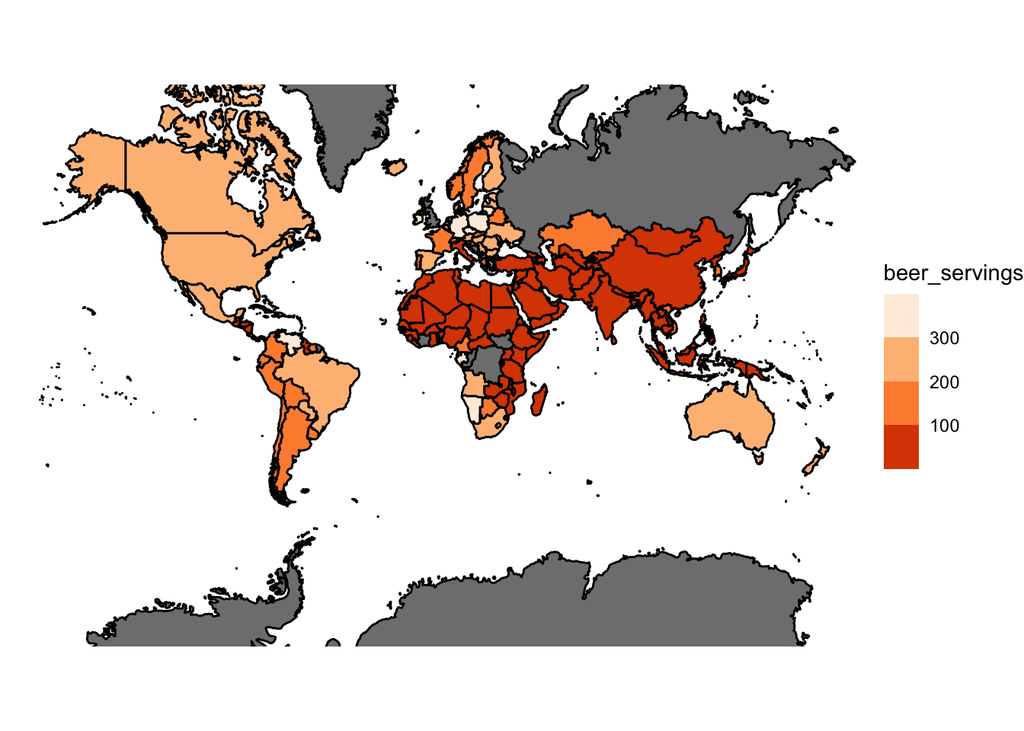

```r
world_map <- ggplot2::map_data("world")
world_map <- world_map %>%
   rename(country = region)
world_alcohol <- full_join(world_map,alcohol_df)
ggplot(data = world_alcohol, aes(x = long, y = lat, group = group)) +
  geom_polygon(colour = "black", aes(fill = beer_servings)) +
  coord_map(projection = "mercator", xlim=c(-180,180)) +
  theme_void() +
  scale_fill_fermenter(palette = "Oranges")
```

Question 2 (5 points). Give an example of a question of interest about the alcohol data where you would want to construct a visualization other than a map to answer the question. What type of visualization would you construct instead?

- If you wanted to look at the relationship between spirit servings and beer servings, you could make a scatterplot or a stacked bar chart that would do a better job of showing that relationship than a physical map would.